# Ichthyosis RNA-Seq Analysis (STAR + Charactaristic Direction)

RNA-Seq analysis of Ichthyosis vs. Control samples. Prior to the analysis, the data was mapped by using STAR. This code includes steps of: * Quantification - by using featureCounts * Filteration & normaliztion steps * Differntial Expression Analysis - by using Characteristic Direction

## Pre-processing of the data

First, we would like to set the directory and get access to the BAM files which were the output of the mapping step with STAR

```r
# get all the BAM files
bam_files <- list.files(path='/Volumes/ShaiM/Netherton/Shai', pattern = ".bam")
bam_files
```

```
##  [1] "004-NW_AACCAG_L001_R1_001.fastq-outputAligned.sortedByCoord.out.bam"
##  [2] "010-NW_AACCAG_L002_R1_001.fastq-outputAligned.sortedByCoord.out.bam"
##  [3] "091-CS_GCACTA_L001_R1_001.fastq-outputAligned.sortedByCoord.out.bam"
##  [4] "112-CS-P14_ACCTCA_L001_R1_001.fastq-outputAligned.sortedByCoord.out.bam"
##  [5] "133-ACS_GTGCTT_L001_R1_001.fastq-outputAligned.sortedByCoord.out.bam"
##  [6] "134-CS_AGTGAG_L002_R1_001.fastq-outputAligned.sortedByCoord.out.bam"
##  [7] "140-ACS_GCACTA_L002_R1_001.fastq-outputAligned.sortedByCoord.out.bam"
##  [8] "155-JB_AAGCCT_L001_R1_001.fastq-outputAligned.sortedByCoord.out.bam"
##  [9] "157-CC_GTCGTA_L001_R1_001.fastq-outputAligned.sortedByCoord.out.bam"
## [10] "159-JP_AAGCCT_L002_R1_001.fastq-outputAligned.sortedByCoord.out.bam"
## [11] "182-ACS_ACCTCA_L002_R1_001.fastq-outputAligned.sortedByCoord.out.bam"
## [12] "238-ACS_GTGCTT_L002_R1_001.fastq-outputAligned.sortedByCoord.out.bam"
## [13] "48-NS_TGGTGA_L002_R1_001.fastq-outputAligned.sortedByCoord.out.bam"
## [14] "52-NS_TGGTGA_L001_R1_001.fastq-outputAligned.sortedByCoord.out.bam"
## [15] "67-NS_AGTGAG_L001_R1_001.fastq-outputAligned.sortedByCoord.out.bam"
## [16] "CMH_100_11-NS_GTGCTT_L002_R1_001.fastq-outputAligned.sortedByCoord.out.bam"
## [17] "CON027_GTCGTA_L002_R1_001.fastq-outputAligned.sortedByCoord.out.bam"
## [18] "MM-014-NS-LS_AAGCCT_L002_R1_001.fastq-outputAligned.sortedByCoord.out.bam"
```

## Quantification by using featureCounts

Now we would like to quantify the data in order to check how many reads are assigned to each gene

```r
knitr::opts_knit$set(root.dir = '/Volumes/ShaiM/Netherton/Shai')

for (bam_file in bam_files) {
  bam_counted_features <- Rsubread::featureCounts(files = bam_file,
                                                  annot.ext = "/Volumes/ShaiM/Netherton/Shai/Homo_sapiens.GRCh38.87.gtf",
                                                  isGTFAnnotationFile = T,
                                                  GTF.featureType = "exon",
                                                  GTF.attrType = "gene_name")
  # Extract the counts object from the list
  extracted_counts <- bam_counted_features$counts
  extracted_counts_genes <- rownames(bam_counted_features$counts)
  extracted_counts_numbers <- bam_counted_features$counts
  dim(bam_counted_features$counts)
  raw_data <- data.frame(extracted_counts_genes, extracted_counts_numbers)
  # Extract sample name
  sample_name <- strsplit(bam_file, '.', fixed=TRUE)[[1]][1]
  # Add .txt extension
  sample_name_txt <- paste0(sample_name, 'extractedCounts.txt')
  # Write the extracted_counts object to the .txt file
  write.table(raw_data, file=sample_name_txt, sep="\t")
}
```

[output not shown]

[output cut: 790 more lines]

[output not shown]

```r
txt_files <- c(list.files(path="/Volumes/ShaiM/Netherton/Shai", pattern="Counts.txt"))
txt_files
```

```
##  [1] "004-NW_AACCAG_L001_R1_001extractedCounts.txt"
##  [2] "010-NW_AACCAG_L002_R1_001extractedCounts.txt"
##  [3] "091-CS_GCACTA_L001_R1_001extractedCounts.txt"
##  [4] "112-CS-P14_ACCTCA_L001_R1_001extractedCounts.txt"
##  [5] "133-ACS_GTGCTT_L001_R1_001extractedCounts.txt"
##  [6] "134-CS_AGTGAG_L002_R1_001extractedCounts.txt"
##  [7] "140-ACS_GCACTA_L002_R1_001extractedCounts.txt"
##  [8] "155-JB_AAGCCT_L001_R1_001extractedCounts.txt"
##  [9] "157-CC_GTCGTA_L001_R1_001extractedCounts.txt"
## [10] "159-JP_AAGCCT_L002_R1_001extractedCounts.txt"
## [11] "182-ACS_ACCTCA_L002_R1_001extractedCounts.txt"
## [12] "238-ACS_GTGCTT_L002_R1_001extractedCounts.txt"
## [13] "48-NS_TGGTGA_L002_R1_001extractedCounts.txt"
## [14] "52-NS_TGGTGA_L001_R1_001extractedCounts.txt"
## [15] "67-NS_AGTGAG_L001_R1_001extractedCounts.txt"
## [16] "CMH_100_11-NS_GTGCTT_L002_R1_001extractedCounts.txt"
## [17] "CON027_GTCGTA_L002_R1_001extractedCounts.txt"
## [18] "MM-014-NS-LS_AAGCCT_L002_R1_001extractedCounts.txt"
```

## Ploting PCA

We will use edgeR & DESeq package for this purpose

```r
pca_data <- readDGE(txt_files)
```

```r
group <- factor(c("Ichthyosis","Ichthyosis","Control","Control","Control","Control","Control",
                  "Control","Control","Control","Control","Control","Ichthyosis",
                  "Ichthyosis","Ichthyosis","Ichthyosis","Control","Ichthyosis"))
```

```r
pca_data$samples$group <- group
```

```r
cds <- newCountDataSet(pca_data$counts,group )
```

```r
cds <- estimateSizeFactors(cds)
```

```r
sizeFactors(cds)
```

```
##        004-NW_AACCAG_L001_R1_001extractedCounts
##                                       1.5087111
##        010-NW_AACCAG_L002_R1_001extractedCounts
##                                       1.6749942
##        091-CS_GCACTA_L001_R1_001extractedCounts
##                                       0.8691579
##    112-CS-P14_ACCTCA_L001_R1_001extractedCounts
##                                       1.1166355
##       133-ACS_GTGCTT_L001_R1_001extractedCounts
##                                       1.4599302
##        134-CS_AGTGAG_L002_R1_001extractedCounts
##                                       0.8924690
##       140-ACS_GCACTA_L002_R1_001extractedCounts
##                                       0.4345006
##        155-JB_AAGCCT_L001_R1_001extractedCounts
##                                       1.1774551
##        157-CC_GTCGTA_L001_R1_001extractedCounts
##                                       1.5956829
##        159-JP_AAGCCT_L002_R1_001extractedCounts
##                                       1.0154084
##       182-ACS_ACCTCA_L002_R1_001extractedCounts
##                                       0.7433377
##       238-ACS_GTGCTT_L002_R1_001extractedCounts
##                                       1.4109486
##         48-NS_TGGTGA_L002_R1_001extractedCounts
##                                       0.8558621
##         52-NS_TGGTGA_L001_R1_001extractedCounts
##                                       0.7243296
##         67-NS_AGTGAG_L001_R1_001extractedCounts
##                                       1.3347837
## CMH_100_11-NS_GTGCTT_L002_R1_001extractedCounts
##                                       0.3065837
##        CON027_GTCGTA_L002_R1_001extractedCounts
##                                       1.5490531
##  MM-014-NS-LS_AAGCCT_L002_R1_001extractedCounts
##                                       1.0894572
```

```r
head( counts(cds, normalized=T))
```

```
##            Samples
## Tags        004-NW_AACCAG_L001_R1_001extractedCounts
##   DDX11L1                                    0.00000
##   WASH7P                                    55.67667
##   MIR6859-1                                  0.00000
##   MIR1302-2                                  0.00000
##   FAM138A                                    0.00000
##   OR4G4P                                     0.00000
##            Samples
## Tags        010-NW_AACCAG_L002_R1_001extractedCounts
##   DDX11L1                                   0.000000
##   WASH7P                                   65.074853
##   MIR6859-1                                 4.179119
##   MIR1302-2                                 0.000000
##   FAM138A                                   0.000000
##   OR4G4P                                    0.000000
##            Samples
## Tags        091-CS_GCACTA_L001_R1_001extractedCounts
##   DDX11L1                                   0.000000
##   WASH7P                                   44.871017
##   MIR6859-1                                 3.451617
##   MIR1302-2                                 0.000000
##   FAM138A                                   0.000000
##   OR4G4P                                    0.000000
##            Samples
## Tags        112-CS-P14_ACCTCA_L001_R1_001extractedCounts
##   DDX11L1                                       0.000000
##   WASH7P                                       46.568465
##   MIR6859-1                                     1.791095
##   MIR1302-2                                     0.000000
##   FAM138A                                       0.000000
##   OR4G4P                                        0.000000
##            Samples
## Tags        133-ACS_GTGCTT_L001_R1_001extractedCounts
##   DDX11L1                                     0.00000
##   WASH7P                                     70.55132
##   MIR6859-1                                   0.00000
##   MIR1302-2                                   0.00000
##   FAM138A                                     0.00000
##   OR4G4P                                      0.00000
```

[output cut: 89 more lines]

```
## Tags        CON027_GTCGTA_L002_R1_001extractedCounts
##   DDX11L1                                   0.000000
##   WASH7P                                  104.580014
##   MIR6859-1                                 1.936667
##   MIR1302-2                                 0.000000
##   FAM138A                                   0.000000
##   OR4G4P                                    0.000000
##            Samples
## Tags        MM-014-NS-LS_AAGCCT_L002_R1_001extractedCounts
##   DDX11L1                                         0.000000
##   WASH7P                                         86.281501
##   MIR6859-1                                       8.260995
##   MIR1302-2                                       0.000000
##   FAM138A                                         0.000000
##   OR4G4P                                          0.000000
```

```r
cds <- estimateDispersions(cds)
```

```r
cdsFull <- newCountDataSet(pca_data$counts, pca_data$samples)
```

```r
cdsFull <- estimateSizeFactors(cdsFull)
```

```r
cdsFullBlind <- estimateDispersions(cdsFull, method="blind")
```

```r
vsdFull <- varianceStabilizingTransformation( cdsFullBlind)
```

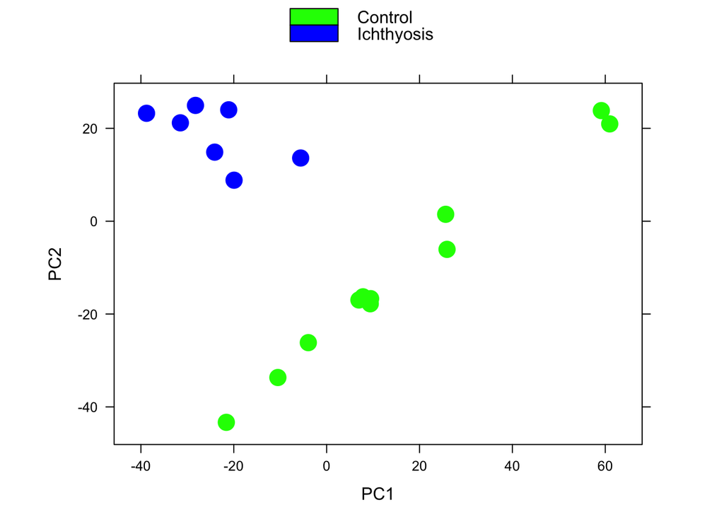

```r
print(plotPCA(vsdFull, intgroup = "group"))
```